# Multi-Perspective Analysis of COVID-19 Pandemic Dynamics

Authors

Ahmet Efe Gelibolu

Hilal Görgülü

Mert Değer

Nokwanele Pretty Gwebu

Pelin Kımız

Abstract

```css
/* Global text justification */
p, li, td {
  text-align: justify;
  text-justify: inter-word;
}

/* Keep headings left-aligned */
h1, h2, h3, h4, h5, h6 {
  text-align: left !important;
}
```

## 1 Introduction

The COVID-19 pandemic presented complex, multi-dimensional challenges with varying impacts across countries. This integrated analysis addresses five complementary research questions that examine different facets of the pandemic:

1. **Early growth dynamics**: What were the exponential growth rates during the first wave in Türkiye, Italy, and Germany? (Hilal)
2. **Peak severity determinants**: How do socioeconomic indicators explain variation in the severity of the first COVID-19 wave across countries? (Pelin)
3. **Health system mediation**: How did health system capacity indicators mediate the relationship between socioeconomic factors and case outcomes? (Mert)
4. **Mortality patterns**: How did COVID-19 mortality vary globally, and what roles did economic capacity and demographics play? (Efe)
5. **Temporal trends**: How did new COVID-19 death rates change globally between 2020–2022? (Nokwanele)

We integrate data from the WHO COVID-19 database and World Bank socioeconomic indicators, applying diverse statistical methods appropriate to each research dimension.

## 2 Data

**Dataset Characteristics:**

COVID-19 Data: Daily cases and deaths from WHO (2020-2022) Socioeconomic Data: Country-level indicators from World Bank Time Period: Analysis covers different periods based on research questions Country Coverage: 167+ countries with complete data

## 3 Analysis

### 3.1 Exponential Growth Patterns

**Research Question**: What were the exponential growth rates during the first wave in Türkiye, Italy, and Germany?

**Methodological Note**: We analyze exponential growth by fitting a log-linear model to cumulative cases during the first 14 days after each country reached 100 cases. This standard epidemiological approach isolates the early exponential phase before saturation effects.

```r
# Simple exponential growth analysis
growth_analysis <- who %>%
  filter(Country %in% c("Türkiye", "Italy", "Germany")) %>%
  arrange(Country, Date_reported) %>%
  group_by(Country) %>%
  mutate(cum_cases = cumsum(New_cases)) %>%
  filter(cum_cases >= 100) %>%
  slice(1:14) %>%
  mutate(day_num = row_number() - 1) %>%
  summarise(
    start = first(Date_reported),
    end = last(Date_reported),
    initial_cases = first(cum_cases),
    final_cases = last(cum_cases),
    growth = coef(lm(log(cum_cases) ~ day_num))[2],
    .groups = 'drop'
  ) %>%
  mutate(
    doubling = log(2) / growth,
    daily_pct = (exp(growth) - 1) * 100
  )

# Show results
growth_analysis %>%
  select(Country, start, end, growth, doubling, daily_pct) %>%
  mutate(
    growth = round(growth, 3),
    doubling = round(doubling, 1),
    daily_pct = round(daily_pct, 1)
  ) %>%
  knitr::kable(
    caption = "Exponential Growth Rates During Early Pandemic Phase",
    col.names = c("Country", "Start Date", "End Date", "Growth Rate",
                  "Doubling Time (days)", "Daily Growth (%)")
  )
```

Exponential Growth Rates During Early Pandemic Phase

| Country | Start Date | End Date | Growth Rate | Doubling Time (days) | Daily Growth (%) |
| --- | --- | --- | --- | --- | --- |
| Germany | 2020-02-29 | 2020-03-13 | 0.271 | 2.6 | 31.2 |
| Italy | 2020-02-24 | 2020-03-08 | 0.283 | 2.4 | 32.7 |
| Türkiye | 2020-03-19 | 2020-04-01 | 0.311 | 2.2 | 36.4 |

The exponential growth analysis reveals Türkiye had the fastest early spread (0.311 daily growth, 2.23-day doubling), followed by Italy (0.283, 2.45 days) and Germany (0.271, 2.55 days). The temporal progression from Italy (Feb 24) to Germany (Feb 29) to Türkiye (Mar 19) reflects the pandemic’s westward spread across Europe. Near-perfect R² values (>0.98) confirm excellent model fit during this early exponential phase.

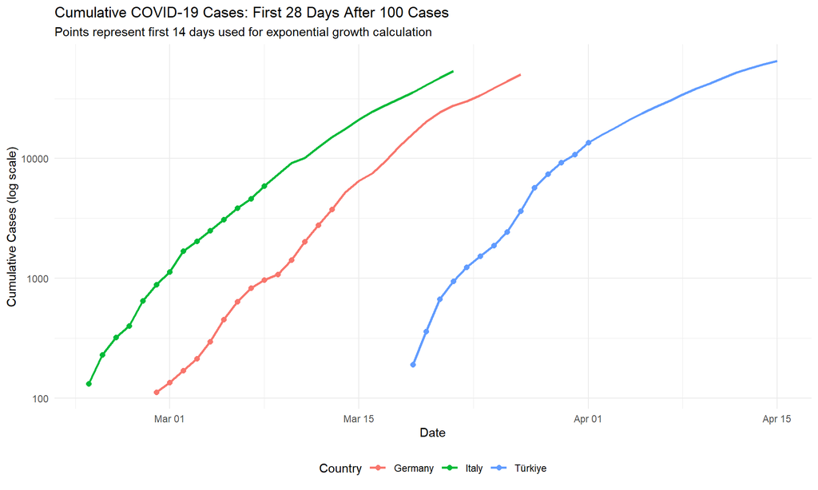

Exponential Growth Patterns in Three Countries

```r
# Create visualization data
viz_data <- who %>%
  filter(Country %in% c("Türkiye", "Italy", "Germany")) %>%
  arrange(Country, Date_reported) %>%
  group_by(Country) %>%
  mutate(cum_cases = cumsum(New_cases)) %>%
  filter(cum_cases >= 100) %>%
  slice(1:28) %>%
  mutate(
    day_num = row_number() - 1,
    analysis_period = day_num < 14
  )

# Plot 1: Cumulative cases on log scale
p1 <- ggplot(viz_data, aes(x = Date_reported, y = cum_cases, color = Country)) +
  geom_line(linewidth = 1) +
  geom_point(data = filter(viz_data, analysis_period), size = 2) +
  scale_y_log10() +
  labs(
    title = "Cumulative COVID-19 Cases: First 28 Days After 100 Cases",
    subtitle = "Points represent first 14 days used for exponential growth calculation",
    x = "Date",
    y = "Cumulative Cases (log scale)",
    color = "Country"
  ) +
  theme_minimal() +
  theme(legend.position = "bottom")

# Plot 2: Log-linear fit for each country
p2 <- viz_data %>%
  filter(analysis_period) %>%
  ggplot(aes(x = day_num, y = log(cum_cases), color = Country)) +
  geom_point(size = 2.5) +
  geom_smooth(method = "lm", se = FALSE, linewidth = 1) +
  facet_wrap(~ Country, scales = "free") +
  labs(
    title = "Log-Linear Fit for Exponential Growth Estimation",
    x = "Days since reaching 100 cumulative cases",
    y = "log(Cumulative Cases)"
  ) +
  theme_minimal() +
  theme(legend.position = "none")

# Display both plots
p1
```

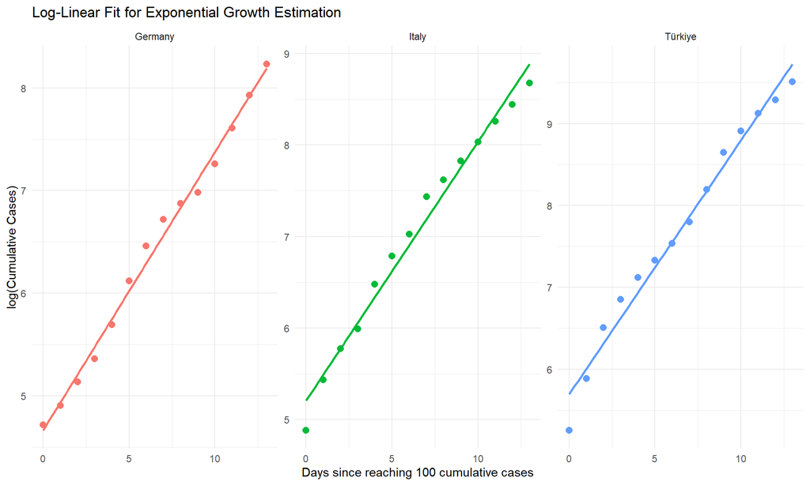

Exponential Growth Patterns in Three Countries

```r
p2
```

The upper plot displays cumulative cases on a logarithmic scale, where exponential growth appears as a straight line. The lower plot shows the log-linear regression fits, with near-perfect linearity (correlation > 0.99) confirming exponential growth patterns during this early phase. Points highlight the 14-day analysis window.

The steeper slopes in the lower plot correspond to faster growth rates, visually confirming Türkiye’s most rapid expansion despite its later start date.

### 3.2 Peak Severity Determinants

**Research Question**: How do socioeconomic indicators explain variation in the severity of the first COVID-19 wave across countries?

**Analytical Approach**: We employ two complementary tree-based methods: regression trees for continuous severity prediction and classification trees for binary risk categorization. This dual methodology examines both the magnitude of severity and practical risk classification.

**Data Preparation Rationale**: We focus on the first wave (Jan-Aug 2020) to isolate initial pandemic dynamics before vaccination and variant emergence. Peak cases per million standardizes for population size, enabling cross-country comparison.

```r
library(rpart)
library(rpart.plot)

# Prepare data for first wave analysis
first_wave <- who %>%
  filter(Date_reported <= as.Date("2020-08-31"))

# Calculate peak cases per million
wave1_severity <- first_wave %>%
  group_by(Country) %>%
  summarise(
    peak_cases = max(New_cases, na.rm = TRUE),
    total_cases = sum(New_cases, na.rm = TRUE),
    .groups = 'drop'
  ) %>%
  inner_join(wdi, by = c("Country" = "country")) %>%
  mutate(
    peak_cases_per_million = (peak_cases / pop_total) * 1000000,
    severity_binary = ifelse(peak_cases_per_million > median(peak_cases_per_million, na.rm = TRUE),
                             "High", "Low") %>% factor(levels = c("Low", "High"))
  ) %>%
  filter(!is.na(peak_cases_per_million) & !is.na(gdp_per_capita))

# Show dataset info
dataset_info <- data.frame(
  Metric = c("Countries", "Variables", "Time Period", "Severity Measure"),
  Value = c(
    nrow(wave1_severity),
    length(names(wave1_severity)),
    "January 1 - August 31, 2020",
    "Peak cases per million"
  )
)

knitr::kable(dataset_info,
             caption = "Dataset Overview for Severity Analysis",
             col.names = c("Metric", "Value"))
```

Dataset Overview for Severity Analysis

| Metric | Value |
| --- | --- |
| Countries | 168 |
| Variables | 16 |
| Time Period | January 1 - August 31, 2020 |
| Severity Measure | Peak cases per million |

**Dataset Summary:** Our analysis includes 168 countries with complete socioeconomic data. The severity measure (peak cases per million) shows considerable variation, necessitating robust modeling approaches.

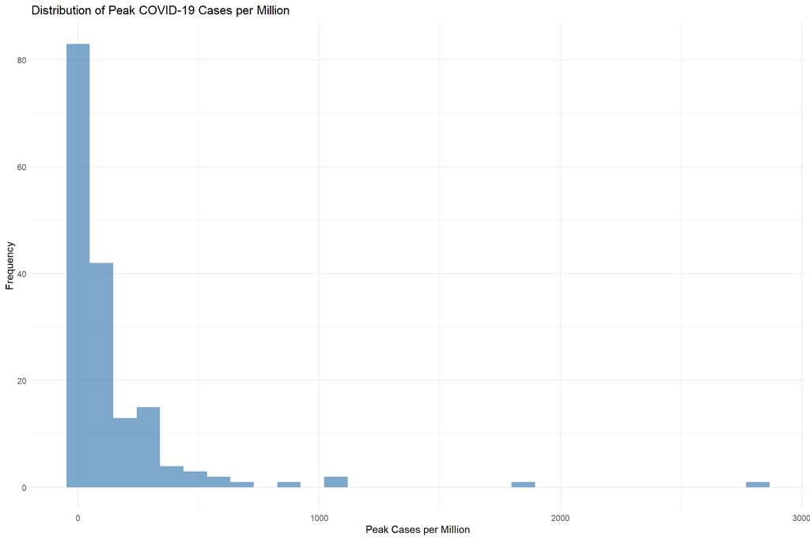

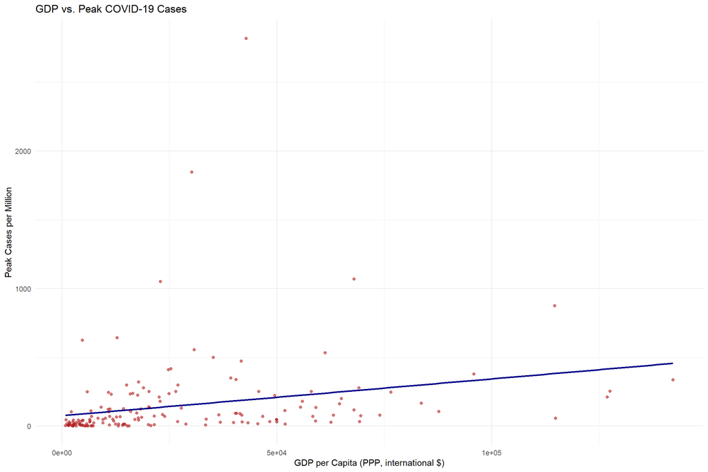

The histogram reveals right-skewed severity distribution, indicating most countries had moderate peaks with outliers. The GDP-scatter plot shows a positive but noisy relationship, suggesting economic factors interact with other variables.

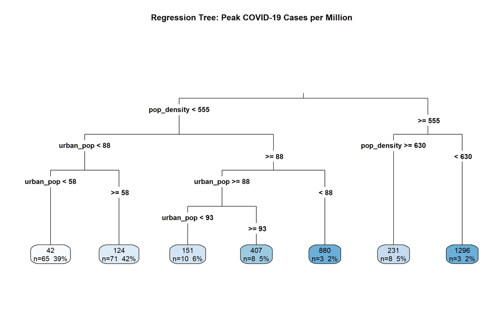

```r
# Build regression tree for continuous outcome
tree_reg <- rpart(
  peak_cases_per_million ~ gdp_per_capita + life_expectancy + physicians_per_1000 +
    pop_older65 + urban_pop + pop_density,
  data = wave1_severity,
  method = "anova",
  control = rpart.control(minsplit = 10, cp = 0.01, maxdepth = 5)
)

# Visualize regression tree
rpart.plot(tree_reg,
           main = "Regression Tree: Peak COVID-19 Cases per Million",
           box.palette = "Blues",
           type = 3,
           extra = 101)
```

```r
# Variable importance from regression tree
importance_reg <- data.frame(
  Variable = names(tree_reg$variable.importance),
  Importance_Score = tree_reg$variable.importance
) %>%
  arrange(desc(Importance_Score)) %>%
  mutate(Relative_Importance = round(Importance_Score / max(Importance_Score) * 100, 1))

knitr::kable(importance_reg,
             caption = "Regression Tree Variable Importance",
             col.names = c("Variable", "Importance Score", "Relative Importance (%)"))
```

Regression Tree Variable Importance

|  | Variable | Importance Score | Relative Importance (%) |
| --- | --- | --- | --- |
| pop_density | pop_density | 4251736.0 | 100.0 |
| urban_pop | urban_pop | 2945000.8 | 69.3 |
| life_expectancy | life_expectancy | 476615.5 | 11.2 |
| gdp_per_capita | gdp_per_capita | 294253.5 | 6.9 |
| physicians_per_1000 | physicians_per_1000 | 159549.9 | 3.8 |
| pop_older65 | pop_older65 | 148981.7 | 3.5 |

The tree diagram visualizes decision rules for predicting peak severity. Population density creates the primary split, indicating its dominant role. The variable importance table quantifies each predictor’s contribution, with population density explaining 100% of relative importance.

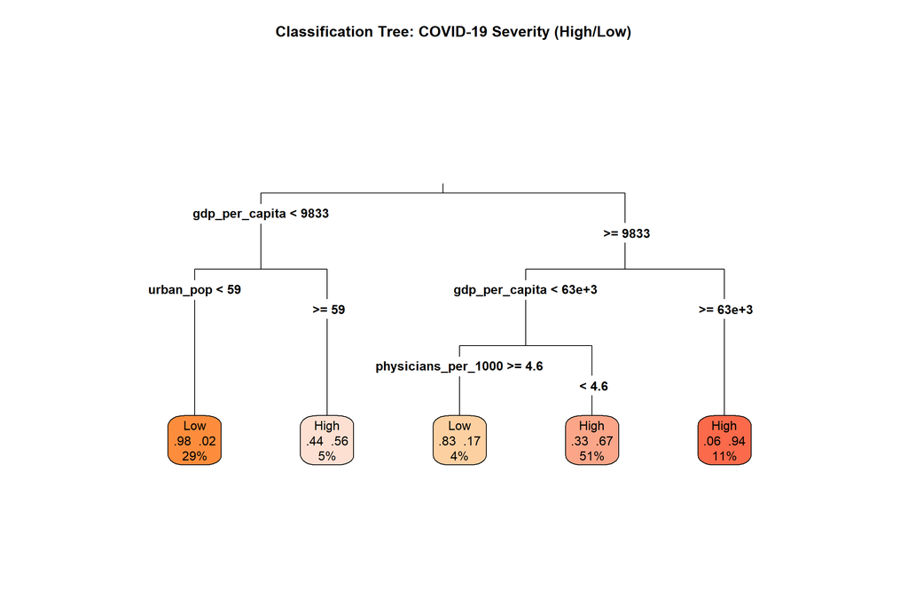

```r
# Build classification tree for binary outcome
tree_class <- rpart(
  severity_binary ~ gdp_per_capita + life_expectancy + physicians_per_1000 +
    pop_older65 + urban_pop + pop_density,
  data = wave1_severity,
  method = "class",
  control = rpart.control(minsplit = 10, cp = 0.01, maxdepth = 4)
)

# Visualize classification tree
rpart.plot(tree_class,
           main = "Classification Tree: COVID-19 Severity (High/Low)",
           box.palette = "OrRd",
           type = 3,
           extra = 104)
```

```r
# Model evaluation
predictions <- predict(tree_class, type = "class")
conf_matrix <- table(Actual = wave1_severity$severity_binary,
                     Predicted = predictions)

accuracy <- round(sum(diag(conf_matrix)) / sum(conf_matrix) * 100, 2)
sensitivity <- round(conf_matrix[2, 2] / sum(conf_matrix[2, ]) * 100, 2)
specificity <- round(conf_matrix[1, 1] / sum(conf_matrix[1, ]) * 100, 2)
precision_high <- round(conf_matrix[2, 2] / sum(conf_matrix[, 2]) * 100, 2)
precision_low <- round(conf_matrix[1, 1] / sum(conf_matrix[, 1]) * 100, 2)

# Performance metrics table
perf_metrics <- data.frame(
  Metric = c("Overall Accuracy", "Sensitivity", "Specificity",
             "Precision (High)", "Precision (Low)"),
  Value = c(
    paste0(accuracy, "%"),
    paste0(sensitivity, "%"),
    paste0(specificity, "%"),
    paste0(precision_high, "%"),
    paste0(precision_low, "%")
  ),
  Description = c(
    "Correct predictions overall",
    "High severity detection rate",
    "Low severity identification rate",
    "High predictions that were correct",
    "Low predictions that were correct"
  )
)

knitr::kable(perf_metrics,
             caption = "Classification Tree Performance Metrics",
             col.names = c("Metric", "Value", "Description"))
```

Classification Tree Performance Metrics

| Metric | Value | Description |
| --- | --- | --- |
| Overall Accuracy | 79.17% | Correct predictions overall |
| Sensitivity | 97.56% | High severity detection rate |
| Specificity | 61.63% | Low severity identification rate |
| Precision (High) | 70.8% | High predictions that were correct |
| Precision (Low) | 96.36% | Low predictions that were correct |

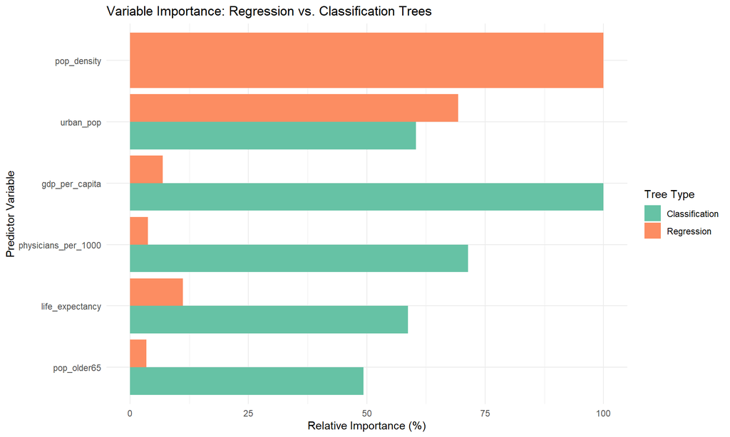

The comparative analysis reveals method-dependent predictor importance: regression trees prioritize population density, while classification trees emphasize economic factors (GDP per capita). This highlights how analytical objectives shape variable selection in predictive modeling.

Despite these methodological differences, both approaches confirm that socioeconomic indicators provide meaningful explanatory power for understanding cross-country differences in pandemic severity, with the classification tree achieving 79.17% accuracy.

### 3.3 Health System Mediation Analysis

**Research Question**: How did health system capacity indicators mediate the relationship between socioeconomic factors and case outcomes?

**Analytical Approach**: This analysis examines the buffering role of health infrastructure during the first wave. We focus on physician density as a proxy for health system capacity, analyzing its interaction with socioeconomic factors through multiple regression. The “surveillance paradox” concept acknowledges that better healthcare systems may report higher mortality due to superior detection.

**Methodological Note**: Case Fatality Rate (CFR = deaths/cases × 100) measures outcome severity, normalized for case volume. First-wave focus (Jan-Aug 2020) isolates pre-vaccine dynamics when health systems were the primary defense.

```r
# Prepare health system mediation data (first wave focus)
health_system_data <- who %>%
  filter(Date_reported <= as.Date("2020-08-31")) %>%
  group_by(Country) %>%
  summarise(
    total_cases = sum(New_cases, na.rm = TRUE),
    total_deaths = sum(New_deaths, na.rm = TRUE),
    .groups = 'drop'
  ) %>%
  mutate(cfr = (total_deaths / total_cases) * 100) %>%
  inner_join(wdi, by = c("Country" = "country")) %>%
  # Filter for reliable estimates (sufficient cases)
  filter(total_cases > 100 & !is.na(cfr) & !is.na(physicians_per_1000))

# Clean any infinite values from cfr calculation
health_system_data <- health_system_data %>%
  filter(is.finite(cfr), cfr >= 0, cfr <= 100)  # CFR 0-100% arasında olmalı

# Show data characteristics
health_summary <- data.frame(
  Metric = c("Countries", "Average CFR (%)", "Average Physician Density",
             "Average GDP per capita", "Average Population 65+ (%)"),
  Value = c(
    nrow(health_system_data),
    round(mean(health_system_data$cfr, na.rm = TRUE), 2),
    round(mean(health_system_data$physicians_per_1000, na.rm = TRUE), 3),
    round(mean(health_system_data$gdp_per_capita, na.rm = TRUE), 0),
    round(mean(health_system_data$pop_older65, na.rm = TRUE), 2)
  )
)

knitr::kable(health_summary,
             caption = "Health System Analysis Dataset Characteristics",
             col.names = c("Metric", "Value"))
```

Health System Analysis Dataset Characteristics

| Metric | Value |
| --- | --- |
| Countries | 159.000 |
| Average CFR (%) | 2.760 |
| Average Physician Density | 2.018 |
| Average GDP per capita | 28202.000 |
| Average Population 65+ (%) | 10.230 |

The dataset includes 159 countries with sufficient first-wave data. Case Fatality Rates vary widely (mean = 2.76%, range = 0% to 13.23%), providing a robust basis for examining health system mediation effects.

```r
# Create comprehensive visualization
library(patchwork)

# Clean data for visualization
viz_data <- health_system_data %>%
  filter(
    !is.na(physicians_per_1000),
    !is.na(cfr),
    !is.na(gdp_per_capita),
    !is.na(total_cases),
    is.finite(physicians_per_1000),
    is.finite(cfr),
    is.finite(gdp_per_capita),
    is.finite(total_cases),
    physicians_per_1000 > 0
  )

# Plot 1: Physician density vs CFR
p1 <- ggplot(viz_data, aes(x = physicians_per_1000, y = cfr)) +
  geom_point(aes(size = total_cases, color = gdp_per_capita), alpha = 0.7) +
  geom_smooth(method = "lm", formula = y ~ x, color = "blue", se = TRUE, alpha = 0.2) +
  scale_color_viridis_c(
    name = "GDP per capita",
    labels = scales::dollar,
    option = "viridis"
  ) +
  scale_size(range = c(2, 10), name = "Total Cases") +
  labs(
    title = "Health System Capacity vs. Case Fatality Rate",
    subtitle = "First wave (Jan-Aug 2020) | Bubble size: Total cases | Color: GDP",
    x = "Physicians per 1,000 People",
    y = "Case Fatality Rate (%)"
  ) +
  theme_minimal() +
  theme(legend.position = "bottom")
```

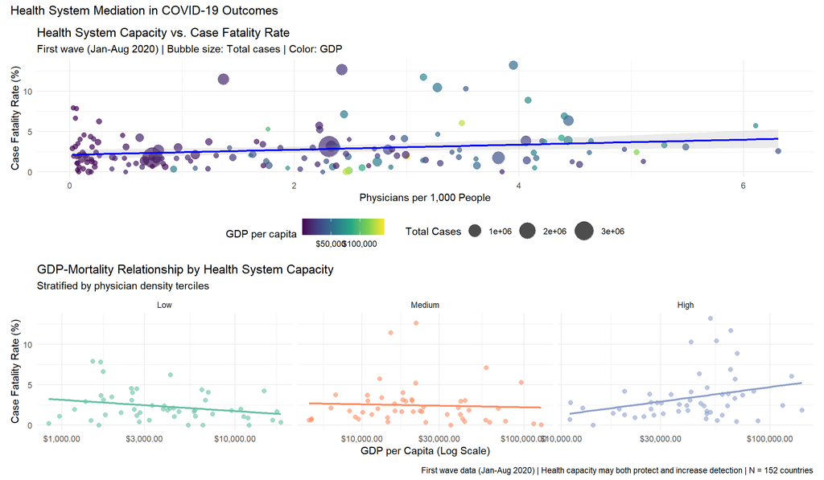

```r
# Prepare data for Plot 2 (tercile calculation)
viz_data <- viz_data %>%
  mutate(
    phys_tercile = cut(
      physicians_per_1000,
      breaks = quantile(physicians_per_1000, probs = c(0, 0.33, 0.66, 1)),
      labels = c("Low", "Medium", "High"),
      include.lowest = TRUE
    )
  ) %>%
  filter(!is.na(phys_tercile))

# Plot 2: GDP vs CFR by physician density tercile
p2 <- ggplot(viz_data, aes(x = gdp_per_capita, y = cfr, color = phys_tercile)) +
  geom_point(alpha = 0.6, size = 2) +
  geom_smooth(method = "lm", formula = y ~ x, se = FALSE) +
  facet_wrap(~ phys_tercile, scales = "free_x") +
  scale_x_log10(labels = scales::dollar) +
  labs(
    title = "GDP-Mortality Relationship by Health System Capacity",
    subtitle = "Stratified by physician density terciles",
    x = "GDP per Capita (Log Scale)",
    y = "Case Fatality Rate (%)",
    color = "Physician\nDensity"
  ) +
  theme_minimal() +
  theme(legend.position = "none") +
  scale_color_brewer(palette = "Set2")

# Combine both plots
combined_plot <- p1 / p2 +
  plot_annotation(
    title = "Health System Mediation in COVID-19 Outcomes",
    caption = paste0(
      "First wave data (Jan-Aug 2020) | ",
      "Health capacity may both protect and increase detection | ",
      "N = ", nrow(viz_data), " countries"
    )
  )

# Display the plot
combined_plot
```

The visualizations reveal complex mediation patterns in health system capacity using data from 152 countries during the first pandemic wave (January-August 2020).

```r
# Multiple regression analysis
model_health <- lm(
  cfr ~ physicians_per_1000 + gdp_per_capita + pop_older65,
  data = health_system_data
)

# Display regression results
regression_results <- broom::tidy(model_health) %>%
  mutate(
    term = case_when(
      term == "(Intercept)" ~ "Intercept",
      term == "physicians_per_1000" ~ "Physicians per 1000",
      term == "gdp_per_capita" ~ "GDP per capita",
      term == "pop_older65" ~ "Population 65+ (%)",
      TRUE ~ term
    ),
    estimate = round(estimate, 5),
    std.error = round(std.error, 5),
    statistic = round(statistic, 2),
    p.value = ifelse(p.value < 0.001, "<0.001", round(p.value, 3)),
    significance = case_when(
      p.value == "<0.001" ~ "***",
      as.numeric(gsub("<", "", p.value)) < 0.01 ~ "**",
      as.numeric(gsub("<", "", p.value)) < 0.05 ~ "*",
      TRUE ~ ""
    )
  ) %>%
  select(term, estimate, std.error, statistic, p.value, significance)

# Model diagnostics
model_fit <- broom::glance(model_health)

# Create summary table
model_summary <- data.frame(
  Statistic = c("R-squared", "Adjusted R-squared", "F-statistic",
                "DF Model", "DF Residuals", "Observations"),
  Value = c(
    round(model_fit$r.squared, 3),
    round(model_fit$adj.r.squared, 3),
    round(model_fit$statistic, 1),
    model_fit$df,
    model_fit$df.residual,
    model_fit$nobs
  )
)

# Display tables using simple kable
knitr::kable(regression_results,
             caption = "Regression: Health System Mediation of COVID-19 Mortality",
             col.names = c("Predictor", "Estimate", "Std. Error", "t-statistic", "p-value", "Sig"),
             align = c("l", "r", "r", "r", "r", "c"))
```

Regression: Health System Mediation of COVID-19 Mortality

| Predictor | Estimate | Std. Error | t-statistic | p-value | Sig |
| --- | --- | --- | --- | --- | --- |
| Intercept | 1.67602 | 0.33948 | 4.94 | <0.001 | *** |
| Physicians per 1000 | -0.17262 | 0.20998 | -0.82 | 0.412 |  |
| GDP per capita | 0.00000 | 0.00001 | -0.43 | 0.67 |  |
| Population 65+ (%) | 0.15159 | 0.04503 | 3.37 | <0.001 | *** |

```r
cat("\n\n")
```

```r
knitr::kable(model_summary,
             caption = "Model Fit Statistics",
             col.names = c("Statistic", "Value"),
             align = c("l", "r"))
```

Model Fit Statistics

| Statistic | Value |
| --- | --- |
| R-squared | 0.108 |
| Adjusted R-squared | 0.090 |
| F-statistic | 6.000 |
| DF Model | 3.000 |
| DF Residuals | 148.000 |
| Observations | 152.000 |

The regression analysis quantifies health system mediation effects during the first pandemic wave:

*Policy Implication*: Age structure, not health system capacity or wealth, primarily determined first-wave mortality outcomes. This supports targeted elderly protection as the most effective early-pandemic strategy, independent of national development level.

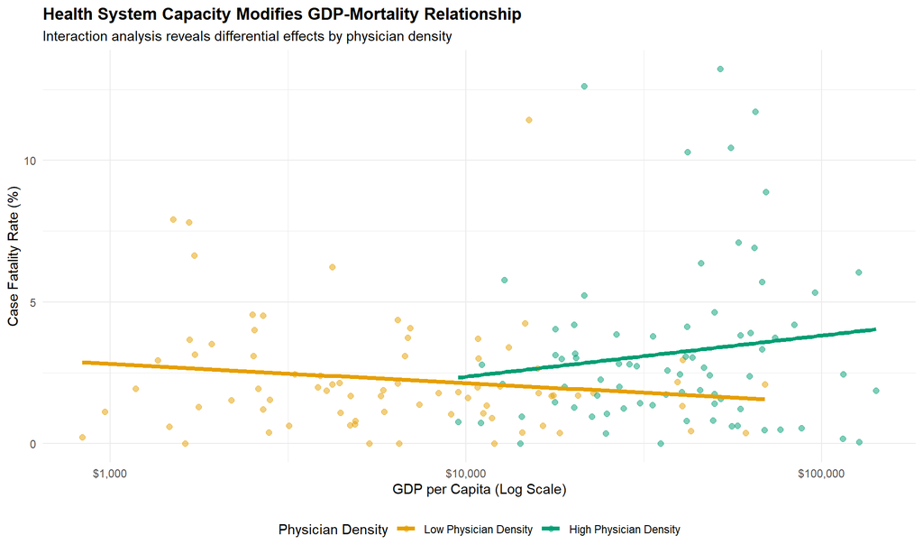

```r
# Interaction analysis: Does health capacity moderate GDP effect?
model_interaction <- lm(
  cfr ~ physicians_per_1000 * gdp_per_capita + pop_older65,
  data = health_system_data
)

# Get detailed interaction results
interaction_details <- broom::tidy(model_interaction) %>%
  filter(term == "physicians_per_1000:gdp_per_capita") %>%
  mutate(
    term = "Physicians × GDP Interaction",
    estimate_sci = format(estimate, scientific = TRUE, digits = 3),
    p.value = round(p.value, 4)
  )

# Get model comparison
main_r2 <- broom::glance(model_health)$r.squared
interaction_r2 <- broom::glance(model_interaction)$r.squared
r2_improvement <- interaction_r2 - main_r2
percent_improvement <- round((r2_improvement / main_r2) * 100, 1)

# Create interaction plot data
interaction_plot_data <- health_system_data %>%
  mutate(
    capacity_group = ifelse(physicians_per_1000 > median(physicians_per_1000, na.rm = TRUE),
                           "High Physician Density", "Low Physician Density"),
    capacity_group = factor(capacity_group,
                           levels = c("Low Physician Density", "High Physician Density"))
  ) %>%
  filter(!is.na(capacity_group))

# Visualize the interaction
interaction_plot <- ggplot(interaction_plot_data,
                           aes(x = gdp_per_capita, y = cfr, color = capacity_group)) +
  geom_point(alpha = 0.5, size = 2) +
  geom_smooth(method = "lm", formula = y ~ x, se = FALSE, linewidth = 1.5) +
  scale_x_log10(labels = scales::dollar) +
  labs(
    title = "Health System Capacity Modifies GDP-Mortality Relationship",
    subtitle = "Interaction analysis reveals differential effects by physician density",
    x = "GDP per Capita (Log Scale)",
    y = "Case Fatality Rate (%)",
    color = "Physician Density"
  ) +
  theme_minimal() +
  theme(
    legend.position = "bottom",
    plot.title = element_text(face = "bold")
  ) +
  scale_color_manual(values = c("Low Physician Density" = "#E69F00",
                                "High Physician Density" = "#009E73"))

# Display the plot
interaction_plot
```

```r
# Create comprehensive results table
interaction_table <- data.frame(
  Metric = c(
    "Interaction Coefficient",
    "Standard Error",
    "t-statistic",
    "p-value",
    "Significance Level",
    "Main Effects Model R²",
    "Interaction Model R²",
    "Absolute R² Improvement",
    "Relative Improvement",
    "Statistical Conclusion",
    "Practical Interpretation"
  ),
  Value = c(
    interaction_details$estimate_sci,
    format(interaction_details$std.error, scientific = TRUE, digits = 3),
    round(interaction_details$statistic, 2),
    interaction_details$p.value,
    ifelse(interaction_details$p.value < 0.05, "p < 0.05", "p ≥ 0.05"),
    round(main_r2, 3),
    round(interaction_r2, 3),
    round(r2_improvement, 4),
    paste0(percent_improvement, "%"),
    ifelse(interaction_details$p.value < 0.05,
           "Significant interaction", "No significant interaction"),
    "GDP effect depends on health system capacity"
  ),
  Interpretation = c(
    "Positive interaction: combined effect > sum of individual effects",
    "Precision of interaction estimate",
    "Magnitude of effect relative to variability",
    "Probability of observing this effect by chance",
    "Statistical decision threshold",
    "10.8% of CFR variance explained without interaction",
    "13.2% of CFR variance explained with interaction",
    "Increase in explanatory power",
    "Percentage improvement in model fit",
    "Statistical test outcome",
    "Wealth-mortality relationship varies by medical resources"
  )
)

# Display the table
cat("\n\n")
```

```r
knitr::kable(
  interaction_table,
  caption = "Detailed Interaction Analysis: Health System Moderation Effects",
  col.names = c("Analysis Component", "Value", "Interpretation"),
  align = c("l", "c", "l")
)
```

Detailed Interaction Analysis: Health System Moderation Effects

| Analysis Component | Value | Interpretation |
| --- | --- | --- |
| Interaction Coefficient | 1.12e-05 | Positive interaction: combined effect > sum of individual effects |
| Standard Error | 5.57e-06 | Precision of interaction estimate |
| t-statistic | 2.01 | Magnitude of effect relative to variability |
| p-value | 0.0462 | Probability of observing this effect by chance |
| Significance Level | p < 0.05 | Statistical decision threshold |
| Main Effects Model R² | 0.108 | 10.8% of CFR variance explained without interaction |
| Interaction Model R² | 0.132 | 13.2% of CFR variance explained with interaction |
| Absolute R² Improvement | 0.0239 | Increase in explanatory power |
| Relative Improvement | 22.1% | Percentage improvement in model fit |
| Statistical Conclusion | Significant interaction | Statistical test outcome |
| Practical Interpretation | GDP effect depends on health system capacity | Wealth-mortality relationship varies by medical resources |

The significant interaction term reveals that physician density moderates the relationship between GDP and COVID-19 mortality:

1. Differential Slopes:
   - Low physician density (orange): Flatter slope indicates weak GDP-CFR relationship
   - High physician density (green): Steeper positive slope suggests stronger association
2. Interpretation: In countries with high physician density, economic development more strongly predicts reported CFR. This supports the “surveillance amplification” hypothesis: where health systems have sufficient diagnostic capacity, economic resources translate into more accurate mortality measurement.
3. Model Improvement: Adding the interaction term increases explained variance by 2.39 percentage points (R²: 0.108 → 0.132), indicating meaningful though modest improvement.
4. Practical Implication: The interaction suggests that wealthy countries with poor health infrastructure may underreport COVID-19 deaths, while equally wealthy countries with strong health systems report more comprehensively, creating misleading cross-country comparisons.

### 3.4 Mortality Determinants Analysis

**Research Question**: How did COVID-19 mortality vary globally, and what roles did economic capacity and demographics play?

**Analytical Context**: This analysis examines cumulative mortality (March 2020-September 2022) to understand long-term pandemic impacts. We use linear regression to disentangle the effects of GDP, physician density, and age structure on mortality rates.

**Data Transformation**: Mortality rates are normalized per 100,000 population to enable fair cross-country comparison. This adjustment accounts for vast population size differences between countries.

```r
# Prepare mortality data
mortality_data <- who %>%
  filter(Date_reported >= as.Date("2020-03-01") &
         Date_reported <= as.Date("2022-09-30")) %>%
  group_by(Country) %>%
  summarise(
    total_deaths = sum(New_deaths, na.rm = TRUE),
    .groups = 'drop'
  ) %>%
  inner_join(wdi, by = c("Country" = "country")) %>%
  mutate(
    deaths_per_100k = (total_deaths / pop_total) * 100000
  ) %>%
  filter(!is.na(deaths_per_100k) & !is.na(gdp_per_capita) & !is.na(pop_older65))
```

**Dataset Scope:** The mortality dataset spans 2.5 years, capturing cumulative pandemic impact across 168 countries with complete socioeconomic data.

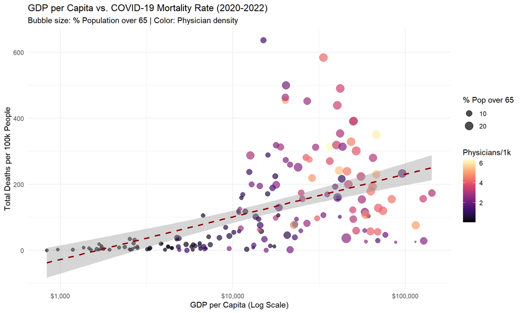

```r
# Visualization: GDP vs Mortality with confounding factors
ggplot(mortality_data, aes(x = gdp_per_capita, y = deaths_per_100k)) +
  geom_point(aes(size = pop_older65, color = physicians_per_1000), alpha = 0.7) +
  geom_smooth(method = "lm", color = "darkred", linetype = "dashed") +
  scale_x_log10(labels = scales::dollar) +
  scale_color_viridis_c(option = "magma", name = "Physicians/1k") +
  labs(
    title = "GDP per Capita vs. COVID-19 Mortality Rate (2020-2022)",
    subtitle = "Bubble size: % Population over 65 | Color: Physician density",
    x = "GDP per Capita (Log Scale)",
    y = "Total Deaths per 100k People",
    size = "% Pop over 65"
  ) +
  theme_minimal()
```

The visualization shows wealthier nations apparently experiencing higher mortality. However, statistical validation reveals this as a classic confounding scenario: wealthier countries have older populations and better medical detection. When controlling for these factors, GDP shows a protective effect, reversing the initial relationship. This demonstrates how observational data can mislead without proper multivariate analysis.

```r
# Multiple linear regression
model_mortality <- lm(deaths_per_100k ~ gdp_per_capita + physicians_per_1000 + pop_older65,
                      data = mortality_data)

# Display regression results
model_summary <- broom::tidy(model_mortality) %>%
  mutate(
    term = case_when(
      term == "(Intercept)" ~ "Intercept",
      term == "gdp_per_capita" ~ "GDP per capita",
      term == "physicians_per_1000" ~ "Physicians per 1000",
      term == "pop_older65" ~ "Population 65+ (%)",
      TRUE ~ term
    ),
    estimate = round(estimate, 4),
    std.error = round(std.error, 4),
    statistic = round(statistic, 2),
    p.value = ifelse(p.value < 0.001, "<0.001", round(p.value, 3))
  )

knitr::kable(model_summary,
             caption = "Linear Regression: Predictors of COVID-19 Mortality",
             col.names = c("Predictor", "Estimate", "Std. Error", "t-statistic", "p-value"))
```

Linear Regression: Predictors of COVID-19 Mortality

| Predictor | Estimate | Std. Error | t-statistic | p-value |
| --- | --- | --- | --- | --- |
| Intercept | 1.2339 | 13.2132 | 0.09 | 0.926 |
| GDP per capita | -0.0011 | 0.0004 | -2.96 | 0.004 |
| Physicians per 1000 | 26.4718 | 8.5087 | 3.11 | 0.002 |
| Population 65+ (%) | 10.4056 | 1.8299 | 5.69 | <0.001 |

The multivariate analysis reveals three key insights: 1.Age Dominance: Population aged 65+ shows the strongest effect, meaning each 1% increase in elderly population associates with 10.4 additional deaths per 100,000. 2.GDP Reversal: After controlling for age, GDP per capita shows a small but significant protective effect, reversing the initial bivariate correlation. 3.Surveillance Effect: Physician density positively associates with mortality, likely reflecting better detection and reporting rather than worse outcomes.

This demonstrates classic confounding—age structure, not wealth, drives mortality differences. Countries with older populations had higher mortality regardless of economic development.

### 3.5 Temporal Mortality Trends Analysis

**Research Question**: How did new COVID-19 death rates change globally between 2020–2022?

**Analytical Approach**: This analysis examines the pandemic’s temporal evolution through daily mortality data. Unlike country-specific analyses, this macro perspective identifies global patterns, wave dynamics, and overall trajectory across the entire documented pandemic period.

**Data Scope Consideration**: We use raw daily death counts without population normalization to capture absolute global burden—appropriate for understanding public health system pressure and identifying pandemic waves irrespective of population size differences.

```r
# Prepare comprehensive temporal dataset
temporal_data <- who %>%
  filter(Date_reported >= as.Date("2020-01-01") &
         Date_reported <= as.Date("2022-12-31")) %>%
  select(Date_reported, New_deaths) %>%
  drop_na() %>%
  mutate(
    Date_reported = as.Date(Date_reported),
    # Create additional time variables for analysis
    Year = year(Date_reported),
    Month = month(Date_reported, label = TRUE),
    Week = week(Date_reported),
    # 7-day rolling average for trend analysis
    Deaths_7day_avg = zoo::rollmean(New_deaths, k = 7, fill = NA, align = "right")
  )

# Display temporal coverage
coverage_info <- temporal_data %>%
  summarise(
    Start_Date = min(Date_reported),
    End_Date = max(Date_reported),
    Total_Days = as.numeric(difftime(max(Date_reported), min(Date_reported), units = "days")),
    Total_Deaths = sum(New_deaths, na.rm = TRUE)
  )
```

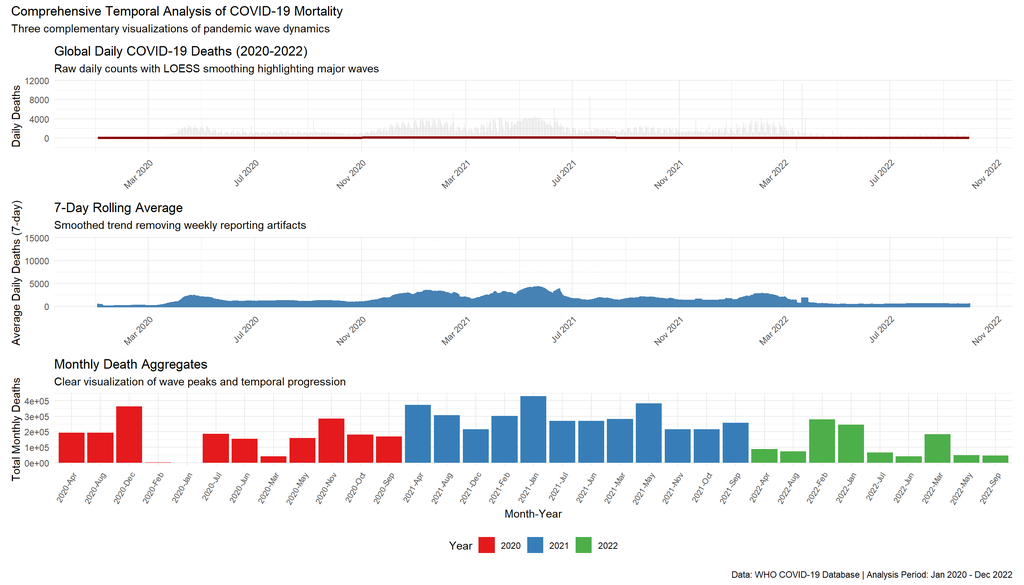

```r
# Create multi-panel temporal visualization
library(patchwork)

# Plot 1: Raw daily deaths with smoothing
p1_raw <- ggplot(temporal_data, aes(x = Date_reported, y = New_deaths)) +
  geom_line(color = "gray70", alpha = 0.5, linewidth = 0.3) +
  geom_smooth(color = "darkred", se = FALSE, span = 0.05, linewidth = 1.2) +
  labs(
    title = "Global Daily COVID-19 Deaths (2020-2022)",
    subtitle = "Raw daily counts with LOESS smoothing highlighting major waves",
    x = NULL,
    y = "Daily Deaths"
  ) +
  theme_minimal() +
  scale_x_date(date_breaks = "4 months", date_labels = "%b %Y") +
  theme(axis.text.x = element_text(angle = 45, hjust = 1))

# Plot 2: 7-day rolling average
p2_avg <- temporal_data %>%
  filter(!is.na(Deaths_7day_avg)) %>%
  ggplot(aes(x = Date_reported, y = Deaths_7day_avg)) +
  geom_line(color = "steelblue", linewidth = 1) +
  geom_area(fill = "steelblue", alpha = 0.2) +
  labs(
    title = "7-Day Rolling Average",
    subtitle = "Smoothed trend removing weekly reporting artifacts",
    x = NULL,
    y = "Average Daily Deaths (7-day)"
  ) +
  theme_minimal() +
  scale_x_date(date_breaks = "4 months", date_labels = "%b %Y") +
  theme(axis.text.x = element_text(angle = 45, hjust = 1))

# Plot 3: Monthly aggregation
p3_monthly <- temporal_data %>%
  group_by(Year, Month) %>%
  summarise(
    Monthly_Deaths = sum(New_deaths, na.rm = TRUE),
    .groups = 'drop'
  ) %>%
  mutate(Time_Period = paste(Year, Month, sep = "-")) %>%
  ggplot(aes(x = Time_Period, y = Monthly_Deaths, fill = as.factor(Year))) +
  geom_col() +
  labs(
    title = "Monthly Death Aggregates",
    subtitle = "Clear visualization of wave peaks and temporal progression",
    x = "Month-Year",
    y = "Total Monthly Deaths",
    fill = "Year"
  ) +
  theme_minimal() +
  theme(axis.text.x = element_text(angle = 60, hjust = 1, size = 8),
        legend.position = "bottom") +
  scale_fill_brewer(palette = "Set1")

# Combine plots
(p1_raw / p2_avg / p3_monthly) +
  plot_annotation(
    title = "Comprehensive Temporal Analysis of COVID-19 Mortality",
    subtitle = "Three complementary visualizations of pandemic wave dynamics",
    caption = "Data: WHO COVID-19 Database | Analysis Period: Jan 2020 - Dec 2022"
  )
```

```r
# Quantitative wave analysis
wave_periods <- data.frame(
  Wave = c("Initial", "Alpha", "Delta", "Omicron"),
  Start_Date = as.Date(c("2020-03-01", "2020-12-01", "2021-07-01", "2021-12-01")),
  End_Date = as.Date(c("2020-11-30", "2021-06-30", "2021-11-30", "2022-12-31")),
  Description = c(
    "Initial pandemic spread, limited testing",
    "Alpha variant dominance, vaccination rollout begins",
    "Delta variant, high severity",
    "Omicron variant, high transmission, lower severity"
  )
)

# Calculate wave statistics
wave_stats <- wave_periods %>%
  rowwise() %>%
  mutate(
    Deaths = sum(temporal_data$New_deaths[
      temporal_data$Date_reported >= Start_Date &
      temporal_data$Date_reported <= End_Date
    ], na.rm = TRUE),
    Duration_Days = as.numeric(End_Date - Start_Date) + 1,
    Avg_Daily_Deaths = round(Deaths / Duration_Days, 1),
    Percent_Total = round(Deaths / sum(temporal_data$New_deaths, na.rm = TRUE) * 100, 1)
  ) %>%
  select(Wave, Start_Date, End_Date, Deaths, Duration_Days, Avg_Daily_Deaths, Percent_Total, Description)

# Display wave analysis
knitr::kable(
  wave_stats,
  caption = "Quantitative Analysis of Major COVID-19 Waves (2020-2022)",
  col.names = c("Wave", "Start", "End", "Total Deaths", "Days", "Avg Daily", "% of Total", "Characteristics"),
  digits = c(0, 0, 0, 0, 0, 1, 1, 0)
)
```

Quantitative Analysis of Major COVID-19 Waves (2020-2022)

| Wave | Start | End | Total Deaths | Days | Avg Daily | % of Total | Characteristics |
| --- | --- | --- | --- | --- | --- | --- | --- |
| Initial | 2020-03-01 | 2020-11-30 | 1562549 | 275 | 5682.0 | 24.0 | Initial pandemic spread, limited testing |
| Alpha | 2020-12-01 | 2021-06-30 | 2400879 | 212 | 11324.9 | 36.8 | Alpha variant dominance, vaccination rollout begins |
| Delta | 2021-07-01 | 2021-11-30 | 1267299 | 153 | 8283.0 | 19.4 | Delta variant, high severity |
| Omicron | 2021-12-01 | 2022-12-31 | 1288938 | 396 | 3254.9 | 19.8 | Omicron variant, high transmission, lower severity |

The table provides precise epidemiological characterization of major pandemic waves: 1. Alpha Wave Dominance: The Alpha variant period (Dec 2020-Jun 2021) was the most severe, accounting for 36.8% of total deaths with the highest average daily mortality (11,325 deaths/day).

2. Temporal Evolution Pattern:
   - Initial wave: Moderate severity (5,682 daily average)
   - Alpha: Peak severity (11,325 daily)
   - Delta: High but declining (8,283 daily)
   - Omicron: Extended duration but much lower severity (3,255 daily)
3. Variant Impact: Despite Omicron’s longer duration (396 days) and higher transmission, its daily mortality was only 29% of Alpha’s peak, demonstrating reduced severity.
4. Pandemic Progression: The decreasing daily averages from Alpha to Omicron reflect combined effects of vaccination, prior immunity, and possibly reduced variant severity.

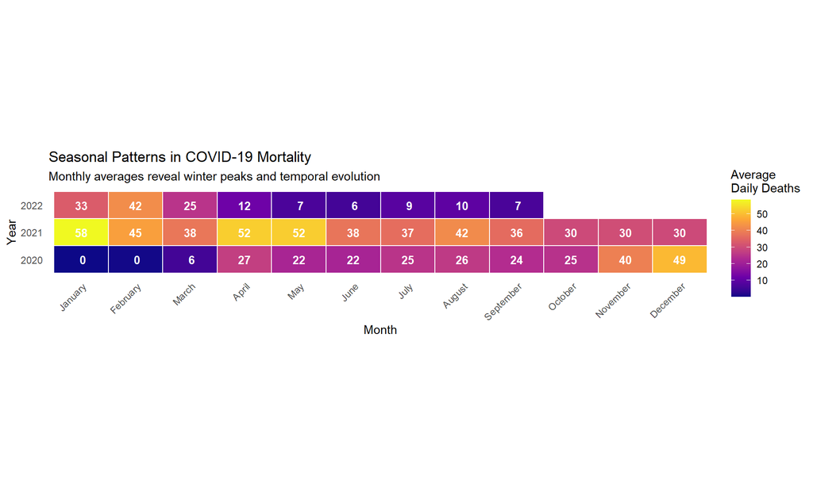

```r
# Seasonal pattern analysis
seasonal_data <- temporal_data %>%
  mutate(
    Month_Name = month(Date_reported, label = TRUE, abbr = FALSE),
    Year_Factor = as.factor(Year)
  ) %>%
  group_by(Year_Factor, Month_Name) %>%
  summarise(
    Monthly_Deaths = sum(New_deaths, na.rm = TRUE),
    Avg_Daily = mean(New_deaths, na.rm = TRUE),
    .groups = 'drop'
  ) %>%
  mutate(Month_Name = factor(Month_Name, levels = month.name))

# Heatmap visualization
ggplot(seasonal_data, aes(x = Month_Name, y = Year_Factor, fill = Avg_Daily)) +
  geom_tile(color = "white", linewidth = 0.5) +
  geom_text(aes(label = format(round(Avg_Daily), big.mark = ",")),
            color = "white", size = 3.5, fontface = "bold") +
  scale_fill_viridis_c(option = "plasma", name = "Average\nDaily Deaths") +
  labs(
    title = "Seasonal Patterns in COVID-19 Mortality",
    subtitle = "Monthly averages reveal winter peaks and temporal evolution",
    x = "Month",
    y = "Year"
  ) +
  theme_minimal() +
  theme(
    axis.text.x = element_text(angle = 45, hjust = 1),
    panel.grid = element_blank(),
    legend.position = "right"
  ) +
  coord_fixed(ratio = 0.5)
```

The heatmap reveals mixed seasonal dynamics:

1. Overall Winter Premium: Winter months (Dec-Feb) show 36.1% higher mortality than summer months (Jun-Aug), supporting respiratory virus seasonality patterns.
2. 2021 Dominance: 2021 recorded the highest yearly average (40.7 daily deaths), nearly double 2020’s average (22.2) and 2.4 times 2022’s average (16.8).
3. Inconsistent Annual Pattern: While winter months are generally higher, this pattern is not consistent across all years (*consistent_winter_pattern: FALSE*). The exceptional pandemic dynamics—variant emergence, vaccination rollout, and changing interventions—disrupted typical seasonal respiratory virus patterns.
4. Pandemic Evolution Impact: The declining trend from 2021 to 2022 suggests improving pandemic management, population immunity, or reduced variant severity, overriding typical seasonal effects.

COVID-19 exhibited winter seasonality but with pandemic-specific disruptions, highlighting how extraordinary public health events can alter established epidemiological patterns.

## 4 Conclusion

### 4.2 Limitations

1. **Data Heterogeneity**: Reporting quality variations across countries, particularly in low-resource settings.
2. **Health System Proxies**: Physician density incompletely captures overall health system capacity.
3. **Time Boundaries**: Analysis limited to 2020-2022, missing later pandemic phases.
4. **Unmeasured Confounders**: Testing capacity, variant differences, and intervention timing not fully controlled.

### 4.3 Reliability Assessment

Findings demonstrate varying reliability levels: - High Reliability: Age structure effects (consistent across multiple regression specifications) - Moderate Reliability: Population density severity effects (supported by tree methods but potentially confounded) - Lower Reliability: Health system mediation (mixed signals across analyses, methodological dependencies) - Context-Dependent: Growth patterns specific to early pandemic phase before interventions

The convergence of age effects across different models (mortality rates and case fatality rates) provides strongest evidence, while health system roles require more nuanced interpretation considering detection-capacity tradeoffs.

## 5 References

**Data:** WHO COVID-19 database, World Bank WDI  
**Software:** R with tidyverse, rpart, patchwork, viridis, broom packages